# Reproducible Research: Peer Assessment 1

## Loading and preprocessing the data

- Downloading the data set and unzip it

```r
download.file("https://d396qusza40orc.cloudfront.net/repdata%2Fdata%2Factivity.zip",
               destfile = "PA1.zip",
               method = "curl"
               )
unzip("PA1.zip")
raw <- read.csv("activity.csv")
```

- Converting raw data from data.frame to data.table for later processing

```r
library("data.table")
raw <- data.table(raw)
```

## What is mean total number of steps taken per day?

- Sum up total number of steps each day, and calculate the mean and median at the same time. The resultant data will be shown in the html file.

```r
plotdata1 <- raw[, list(sum=sum(steps, na.rm=TRUE), mean=mean(steps, na.rm=TRUE),
                     median=as.double(median(steps, na.rm=TRUE))), by=date]
print(plotdata1)
```

```
##           date   sum       mean median
##  1: 2012-10-01     0        NaN     NA
##  2: 2012-10-02   126  0.4375000      0
##  3: 2012-10-03 11352 39.4166667      0
##  4: 2012-10-04 12116 42.0694444      0
##  5: 2012-10-05 13294 46.1597222      0
##  6: 2012-10-06 15420 53.5416667      0
##  7: 2012-10-07 11015 38.2465278      0
##  8: 2012-10-08     0        NaN     NA
##  9: 2012-10-09 12811 44.4826389      0
## 10: 2012-10-10  9900 34.3750000      0
## 11: 2012-10-11 10304 35.7777778      0
## 12: 2012-10-12 17382 60.3541667      0
## 13: 2012-10-13 12426 43.1458333      0
## 14: 2012-10-14 15098 52.4236111      0
```

[output cut: 48 more lines]

- Plot a histogram based on the total number of steps in each day

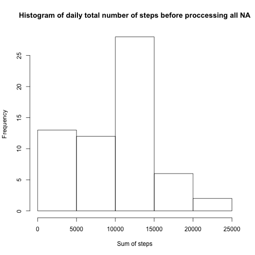

```r
hist(plotdata1$sum, xlab="Sum of steps", ylab="Frequency",
     main="Histogram of daily total number of steps before proccessing all NA")
```

## What is the average daily activity pattern?

- First of all summarize the daily steps by taking the average across all days for each interval. The resultant data will be shown.

```r
plotdata2 <- raw[, list(sum=sum(steps, na.rm=TRUE),
                        average=mean(steps, na.rm=TRUE)), by=interval]
print(plotdata2)
```

```
##      interval sum   average
##   1:        0  91 1.7169811
##   2:        5  18 0.3396226
##   3:       10   7 0.1320755
##   4:       15   8 0.1509434
##   5:       20   4 0.0754717
##  ---
## 284:     2335 249 4.6981132
## 285:     2340 175 3.3018868
## 286:     2345  34 0.6415094
## 287:     2350  12 0.2264151
## 288:     2355  57 1.0754717
```

- Make a line plot with x-axis being the interval and y-axis being average steps

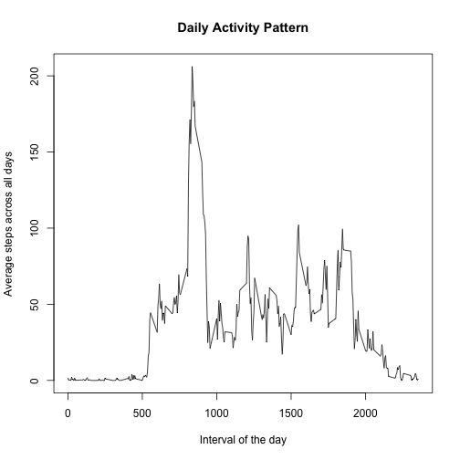

```r
plot(plotdata2$interval, plotdata2$average, type="l",
     xlab="Interval of the day", ylab="Average steps across all days",
     main="Daily Activity Pattern")
```

- Find the interval with the max number of steps across all days

```r
peak <- plotdata2[plotdata2$average == max(plotdata2$average),]
print(peak)
```

```
##    interval   sum  average
## 1:      835 10927 206.1698
```

On average, number of steps reach the peak at **interval 835** with average **206.1698113 steps**

## Imputing missing values

- Compute the total numbers of rows with missing steps

```r
total <- nrow(raw[is.na(raw$steps)])
print(total)
```

```
## [1] 2304
```

Uh-ha, there are **2304** rows with missing data

- Fill up the missing data with mean for that 5 minute interval

```r
## Using a for loop in this way is actually a bad idea as it's significantly slow
## If not for the requirement for a new data set equal to the original one, I
## would have used merge function to do this which is faster but changes the format
## of the dataset a bit.
newraw <- raw
newraw$steps <- as.double(newraw$steps) ##prevent data truncation from double to int
n <- nrow(newraw)
for(i in 1:n) {
   if (is.na(newraw$steps[i])) {
      newraw$steps[i] <- plotdata2[plotdata2$interval==newraw$interval[i],]$average
   }
}
```

- Prepare plot data and generate a new histogram

```r
plotdata3 <- newraw[, list(sum=sum(steps), mean=mean(steps),
                     median=as.double(median(steps))), by=date]
print(plotdata3)
```

```
##           date      sum       mean   median
##  1: 2012-10-01 10766.19 37.3825996 34.11321
##  2: 2012-10-02   126.00  0.4375000  0.00000
##  3: 2012-10-03 11352.00 39.4166667  0.00000
##  4: 2012-10-04 12116.00 42.0694444  0.00000
##  5: 2012-10-05 13294.00 46.1597222  0.00000
##  6: 2012-10-06 15420.00 53.5416667  0.00000
##  7: 2012-10-07 11015.00 38.2465278  0.00000
##  8: 2012-10-08 10766.19 37.3825996 34.11321
##  9: 2012-10-09 12811.00 44.4826389  0.00000
## 10: 2012-10-10  9900.00 34.3750000  0.00000
## 11: 2012-10-11 10304.00 35.7777778  0.00000
## 12: 2012-10-12 17382.00 60.3541667  0.00000
## 13: 2012-10-13 12426.00 43.1458333  0.00000
## 14: 2012-10-14 15098.00 52.4236111  0.00000
```

[output cut: 48 more lines]

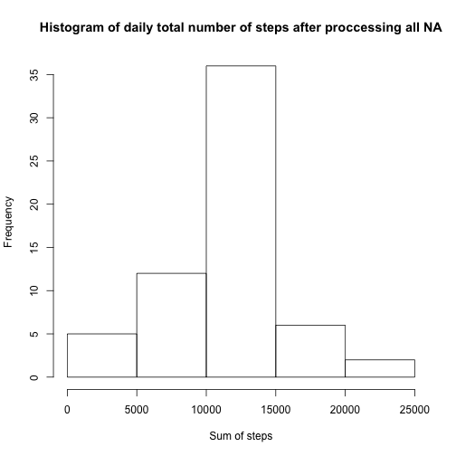

```r
hist(plotdata3$sum, xlab="Sum of steps", ylab="Frequency",
     main="Histogram of daily total number of steps after proccessing all NA")
```

The resultant plot and data do differ from the original ones before inputing all missing data. However, the difference is many on those days when steps are missing. For days having valid step data, there is essentially no change.

## Are there differences in activity patterns between weekdays and weekends?

- Create a new column called ‘wd’ from the initial ‘date’ column, and append the new column to the dataset. Convert the initial date in format “%Y-%m-%d” into dates and derive the “Weekday” and “Weekend” factors.

```r
wd <- newraw$date
names(wd) <- "wd"
newraw <- cbind(newraw, wd)
newraw$wd <- weekdays(as.Date(newraw$wd, format="%Y-%m-%d"))
newraw[(newraw$wd=="Saturday" | newraw$wd=="Sunday"),]$wd <- "Weekend"
newraw[(newraw$wd=="Monday" | newraw$wd=="Tuesday" | newraw$wd=="Wednesday" |
        newraw$wd=="Thursday" | newraw$wd=="Friday"),]$wd <- "Weekday"

newraw$wd <- as.factor(newraw$wd)
```

- Generating the Weekday Vs Weekend line charts

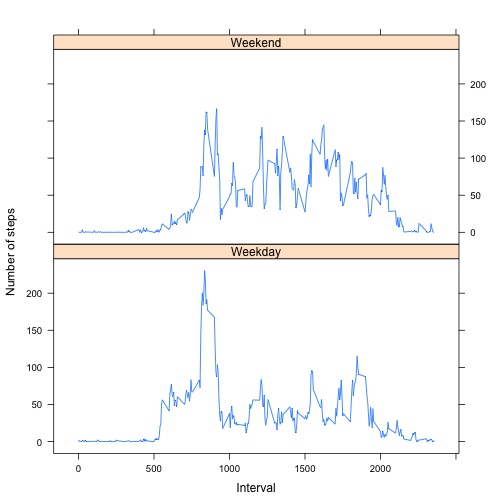

```r
library(lattice)
plotdata4 <- newraw[,list(sum=sum(steps), average=mean(steps)), by=list(wd, interval)]
xyplot(average ~ interval | wd, data = plotdata4, type = "l", layout = c(1,2),
       as.Table = TRUE, xlab = "Interval", ylab = "Number of steps")
```